# Introduction to bdt()

Yan Liu

2021-03-23

The R package **bdt** implements adapted bootstrap diagnostic tool (BDT), originally described in Bahamyirou A, Blais L, Forget A, Schnitzer ME. *Understanding and diagnosing the potential for bias when using machine learning methods with doubly robust causal estimators*. . 2019 Jun;28(6):1637-50. Data-adaptive methods can produce a separation of the two exposure groups in terms of propensity score densities which can lead to biased finite-sample estimates of the treatment effect. **bdt** is based on a bootstrap resampling of the subjects and simulation of the outcome data conditional on observed treatment and covariates in order to diagnose whether the estimation using data-adaptive methods for the propensity score may lead to large bias and poor coverage in the finite sample. For more theoretical details, please refer to the original paper: https://doi.org/10.1177%2F0962280218772065.

## Parameter of interest and Positivity assumption

In the context of causal inference, identifiability of average treatment effects requires some assumptions that allow investigators to write the parameter of interest in terms of the distribution of the observational studies. The common assumptions include consistency, ignorability and positivity. Consider an observational data with $n$ i.i.d. observations on the data structure $O = (W, A, Y)$, where $W$ be the vector of baseline covariates of an individual; $A$ be the observed binary treatment indicator with the value equals to 1 if the subject received the treatment and 0 otherwise; $Y$ be the observed continuous or binary outcome. The parameter of interest is the additive effect conditioning on a set of potential confounders $W$. Positivity assumption requires that the probability of receiving any level of treatment conditioning on every set of covariates must be positivity for all subjects in the population, i.e. $P(A=a|W)>0$ for any $a\in\{0,1\}$.

## Estimation

In this package, we use two estimators: augmented inverse probability of treatment weighted estimator (A-IPTW) and Targeted Maximum Likelihood Estimators (TMLEs) to estimate the average treatment effect (ATE). Doubly robust estimators A-IPTW and TMLE decrease the dependence on the correct specification of the propensity model and only require either outcome model or propensity score model to be correctly specified.

In practice, researchers are typically unaware of the true specification of the propensity score model. To increase the chance of correct model specification, flexible prediction methods, in particular the ensemble learner called ‘SuperLearner’ (SL), are often recommended. SL is a non-parametric methodology that uses cross validation to find an optimal convex combination of the predictions of a library of candidate algorithms defined by the user. However, under some settings the flexibility in the propensity modeling can lead to the selection of strong predictors of the treatment. This would give rise to extreme value of propensity score since these predictors may or may not be real confounders. Both A-IPTW and TMLE estimators involve the inverse of propensity scores. Thus, the highly variable weights can lead to unstable parameter estimates and potential bias. Overall, in the presence of potential positivity violations, flexible modeling of the propensity score give rise to the increment of the bias and variance of the causal effect estimators as compared to parametric methods and the extent of how much they are impacted depends on the estimator. In order to address this issue, one may define different bounds to truncate the probabilities then reduce their standard errors though choice of truncation level is usually ad-hoc.

## Bootstrap diagnostic tool

Bahamyirou et al. presented an adapted version of the diagnostic tool in simulation to illustrate whether the ATE estimators were destablized by the use of SL to fit the propensity score. For a given observed data set, the diagnostic tool which is based on a bootstrap resampling of the subjects, keeps the observed treatment of each resampled subject but simulates the outcome using the information of the two observed subgroups who are treated or not being treated. To expedite the application of this diagnostic tool, we develop **bdt** package to diagnose the instability introduced when flexible modeling method is employed for the estimation of the propensity score. Based on the parametric bootstrap the **bdt** package can provide an optimistic bias estimate by excluding bias due to the model mis-sepcification for the outcome models. Because the outcome model is known and correct in terms of bootstrap data, we can expect that any large estimation errors are caused by the instability of the weights.

Define $Q_{1, W}$ and $Q_{0, W}$ be the conditional expectation of the outcome for subjects who had been treated and not been treated respectively. Our target parameter is $\psi=E(Q_{1,W}-Q_{0, W})$. If we estimate the quantities $Q_{1, n}$ and $Q_{0, n}$, we can obtain a plug-in estimator $\hat{\psi}=\frac{1}{n}\sum_{i=1}^n(Q_{1, n}-Q_{0, n})$ which is set as the “true” effect in the following algorithm. Define $g_n$ be the estimated conditional probabilities of the treatment mechanism. Specifically, we present the BDT algorithm with a continuous outcome as follows. Similar implementations can be easily produced for a binary outcome.

## Steps

- Step 1: Estimate $Q_{1,n}$, $Q_{0,n}$ and simulate $Y^*$. For the two treatment subgroups of subjects with $A=1$ and $A=0$, fit a linear regression of the outcome $Y$ on baseline covariates $W$ respectively where the model only contains main terms of $W$ to predict $Q_{1,n}$ and $Q_{0,n}$ for all subjects and the variance $\hat{\sigma}^2_1$, $\hat{\sigma}^2_0$. New outcome $Y^*$ is simulated on assumed normal distribution with mean $Q_{1,n}$ and variance $\hat{\sigma}^2_1$ for subjects who had been treated, otherwise using mean $Q_{0,n}$ and variance $\hat{\sigma}^2_0$. Transform the three quantities $Q_{1,n}$, $Q_{0,n}$ and $Y^*$ to lie between $[0,1]$. Construct a new data with structure $(W, A, Q_{1,n}, Q_{0,n}, Y^*)$.
- Step 2: Fit logistic regressions on the treatments to estimate propensity scores. The estimated coefficients are denoted as $\hat{\gamma}$.
- Step 3: Sample $n$ subjects with replacement to generate a bootstrap dataset.
- Step 4: Compute the mean of the difference $Q_{1,n}-Q_{0,n}$ and transform it to the original linear scale. Then we obtain the “true” effect with respect to the bootstrap dataset.
- Step 5: Using the coefficients $\hat{\gamma}$ in Stage 2 to estimate the $g_n^{glm}$ for the bootstrap data if user require GLM to estimate ps. Otherwise, use SL methods to estimate $g_n^{sl}$. Then compute the corresponding bounded weights $w$. Construct an augmented bootstrap data with structure $(W, A, Q_{1,n}, Q_{0,n}, Y^*, w)$.
- Step 6: Estimation of target parameters. For the resampled data with simulated outcomes, two estimators TMLE and A-IPTW are applied to estimate the targeted parameter using existed quantities. Compute the error for both approaches. In addition, based on the estimated influence functions to estimate the standard errors and $95\%$ confidence intervals.
- Step 7: Repeat Steps 3 to 6 $M$ times. Then compute the average errors and the coverage rates on $M$ bootstrap samples.

## Example

We use the example as described in the simulation part of Bahamyirou’s paper. In this data, outcome $Y$ is a continuous variable and treatment $A$ is binary with realizations $a \in\{ 1, 0\}$. The baseline covariate set $X$ contains five elements ($W_1, W_2$, $I_1, I_2, P$) where $W_1, W_2$ are two confounders, $P$ is a pure risk factor and $I_1, I_2$ are two instruments. We generate a single data set by setting seed to 1250.

```r
set.seed(1250)
n = 1000
sigma = matrix(c(2, 1, 1, 1), ncol = 2)
W = matrix(rnorm(n*2), ncol = nrow(sigma)) %*% chol(sigma)
W = W + matrix(rep(c(.5, 1),each = n), byrow = FALSE, ncol = 2)
bound = function(x, bounds){
  x[x < min(bounds)] = min(bounds); x[x > max(bounds)] = max(bounds)
  return(x)}
I1 = bound(rnorm(n,mean = 1, sd = 2), c(-3,3))
I2 = bound(rnorm(n,mean = 1, sd = 1.9), c(-3,3))
P = bound(rnorm(n,mean = 1, sd  =1.5), c(-3,3))
X = data.frame(W, I1, I2, P)
colnames(X) = c("W1", "W2", "I1", "I2",  "P")
X$W1 <- bound(X$W1,c(-3,4)); X$W2 <- bound(X$W2,c(-3,4))
A = rbinom(n, 1, plogis(0.2 + X[,"W1"] + 0.3*X[,"I1"] + X[,"W1"]*X[,"I1"]
                         - 0.2*(X[,"W2"] + X[,"I2"])^2 ))
Y = 1 + A + X[,"W1"] + 2*X[,"W2"] + 0.5*(X[,"W1"] + X[,"P"])^2 + rnorm(n)
```

```r
ps = ps(A, X, gform1 = "A~ W1+W2+I1+I2", gform2 = "A~ W1*I1+W2*I2",
         SL.library1 = NULL,
         SL.library2 = c("SL.glm", "SL.glm.interaction"))
summary(ps)
```

```
##
## Summary of estimated probabilities for given method(s):
##
##                                           Min.   1st Qu.    Median      Mean
## P(A=1|W) for all subjects by GLM1 2.102956e-02 0.2683682 0.4872685 0.4830000
## P(A=0|W) for all subjects by GLM1 2.175712e-02 0.3098743 0.5127315 0.5170000
## P(A=1|W) in subgroups A=1 by GLM1 2.102956e-02 0.5056816 0.6580834 0.6232643
## P(A=0|W) in subgroups A=0 by GLM1 8.057866e-02 0.5184360 0.6600685 0.6480400
## P(A=1|W) for all subjects by GLM2 1.902232e-05 0.1452675 0.4435470 0.4830000
## P(A=0|W) for all subjects by GLM2 3.468730e-07 0.1442802 0.5564530 0.5170000
## P(A=1|W) in subgroups A=1 by GLM2 2.775369e-02 0.5451450 0.8531802 0.7430013
## P(A=0|W) in subgroups A=0 by GLM2 3.205494e-02 0.6514146 0.8363458 0.7599026
## P(A=1|W) for all subjects by SL   2.739614e-03 0.1453110 0.4323329 0.4830000
## P(A=0|W) for all subjects by SL   7.324380e-04 0.1469424 0.5676671 0.5170000
## P(A=1|W) in subgroups A=1 by SL   2.237994e-02 0.5670354 0.8458426 0.7462731
## P(A=0|W) in subgroups A=0 by SL   2.447830e-02 0.6542502 0.8350978 0.7629592
##                                     3rd Qu.      Max.
## P(A=1|W) for all subjects by GLM1 0.6901257 0.9782429
## P(A=0|W) for all subjects by GLM1 0.7316318 0.9789704
## P(A=1|W) in subgroups A=1 by GLM1 0.8008275 0.9782429
## P(A=0|W) in subgroups A=0 by GLM1 0.7977143 0.9757636
## P(A=1|W) for all subjects by GLM2 0.8557198 0.9999997
## P(A=0|W) for all subjects by GLM2 0.8547325 0.9999810
## P(A=1|W) in subgroups A=1 by GLM2 0.9761013 0.9999997
## P(A=0|W) in subgroups A=0 by GLM2 0.9494955 0.9999810
## P(A=1|W) for all subjects by SL   0.8530576 0.9992676
## P(A=0|W) for all subjects by SL   0.8546890 0.9972604
## P(A=1|W) in subgroups A=1 by SL   0.9708341 0.9992676
## P(A=0|W) in subgroups A=0 by SL   0.9415370 0.9972604
```

```r
summary(ps)$SL
```

```
##                                        Min.   1st Qu.    Median      Mean
## P(A=1|W) for all subjects by SL 0.002739614 0.1453110 0.4323329 0.4830000
## P(A=0|W) for all subjects by SL 0.000732438 0.1469424 0.5676671 0.5170000
## P(A=1|W) in subgroups A=1 by SL 0.022379936 0.5670354 0.8458426 0.7462731
## P(A=0|W) in subgroups A=0 by SL 0.024478297 0.6542502 0.8350978 0.7629592
##                                   3rd Qu.      Max.
## P(A=1|W) for all subjects by SL 0.8530576 0.9992676
## P(A=0|W) for all subjects by SL 0.8546890 0.9972604
## P(A=1|W) in subgroups A=1 by SL 0.9708341 0.9992676
## P(A=0|W) in subgroups A=0 by SL 0.9415370 0.9972604
```

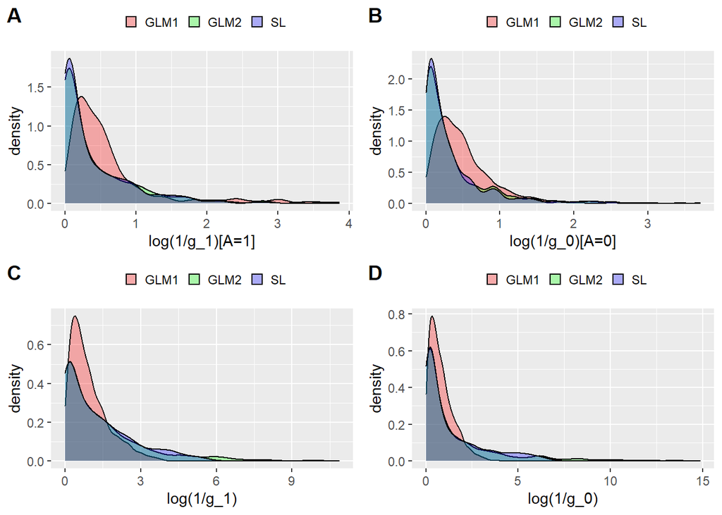

```r
plot(ps)
```

```r
ps$fit_summaries
```

```
## [[1]]
##
## Call:
## glm(formula = gform, family = "binomial", data = data.frame(A,
##     W))
##
## Deviance Residuals:
##     Min       1Q   Median       3Q      Max
## -2.2443  -0.9238  -0.3668   0.8997   2.7792
##
## Coefficients:
##             Estimate Std. Error z value Pr(>|z|)
## (Intercept) -0.10215    0.12502  -0.817    0.414
## W1           1.00625    0.08749  11.501  < 2e-16 ***
## W2          -0.58781    0.10664  -5.512 3.54e-08 ***
## I1           0.38327    0.04747   8.074 6.81e-16 ***
## I2          -0.25654    0.04546  -5.643 1.67e-08 ***
## ---
## Signif. codes:  0 '***' 0.001 '**' 0.01 '*' 0.05 '.' 0.1 ' ' 1
##
## (Dispersion parameter for binomial family taken to be 1)
##
##     Null deviance: 1385.1  on 999  degrees of freedom
## Residual deviance: 1101.3  on 995  degrees of freedom
## AIC: 1111.3
##
## Number of Fisher Scoring iterations: 4
##
##
## [[2]]
##
## Call:
## glm(formula = gform, family = "binomial", data = data.frame(A,
##     W))
##
## Deviance Residuals:
##      Min        1Q    Median        3Q       Max
## -2.62309  -0.61795  -0.05388   0.53519   2.67746
##
## Coefficients:
```

[output cut: 14 more lines]

```
## Residual deviance:  763.66  on 993  degrees of freedom
## AIC: 777.66
##
## Number of Fisher Scoring iterations: 6
##
##
## [[3]]
##
## Call:
## SuperLearner(Y = A, X = W, family = binomial(), SL.library = SL.library)
##
##
##                             Risk       Coef
## SL.glm_All             0.1799564 0.03731483
## SL.glm.interaction_All 0.1261500 0.96268517
```

Next we use *bdt* function to simulate totally 10 bootstrap data sets to estimate the average error of estimators A-IPTW and TMLE and corresponding coverage rates using SL and GLM where the propensity model is included only with main terms (no bounding). In order to make the two estimators be comparable, we first generate 11 random number seeds which are used to simulate the new outcomes and 10 bootstrap data sets. We then run the *bdt* function repeatedly using GLM and SL for the estimation of propensity scores and store the results as the objects $bdt\_glm$ and $bdt\_sl$ respectively. Since we only generate 10 data here, a message “Small number of replications may lead to unreliable estimates.” shows up. Then we also apply *summary()*, *plot()* to two objects to compare the mean errors and coverage rates of two estimators.

```r
m = 10
seeds = sample(1:10000, m+1, rep = FALSE)
gform = "A~W1+W2+I1+I2"
bdt_glm = bdt(Y, A, W=X, M = m, outcome_type = "continuous",
              seed = seeds, gbound = 0, gGLM = TRUE, gform = gform)
```

```
## Small number of replications may lead to unreliable estimates.
##
## Estimating ate using user-supplied regression formula for g
```

```r
summary(bdt_glm)
```

```
##
##
## True simulated data effect:  0.96587
##
## Mean and median bias, SE and coverage rates of AIPTW and TMLE with the ps estimation by GLM:
##
##       MeanBias Med.Bias    SE   Cov.
## AIPTW -0.28297 -0.30923 0.32440 0.7
##  TMLE -0.22382 -0.29816 0.31836 1.0
##
##
## Summary of propensity scores truncated at gbound 0
##
##                        Min.   1st Qu.    Median      Mean   3rd Qu.      Max.
## P(A=1|X) for all 0.02102956 0.2667476 0.4830949 0.4812664 0.6889472 0.9782429
## P(A=0|X) for all 0.02175712 0.3110528 0.5169051 0.5187336 0.7332524 0.9789704
## P(A=1|X) for A=1 0.02102956 0.4983307 0.6580834 0.6208134 0.8005349 0.9782429
## P(A=0|X) for A=0 0.08057866 0.5184360 0.6645014 0.6488948 0.8009483 0.9757636
```

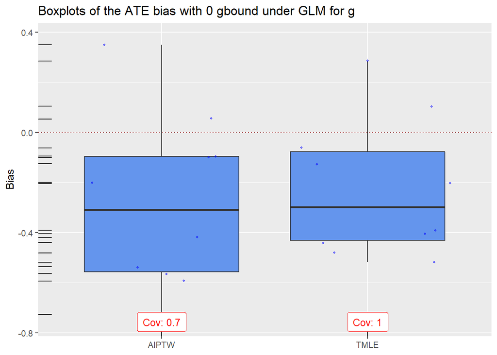

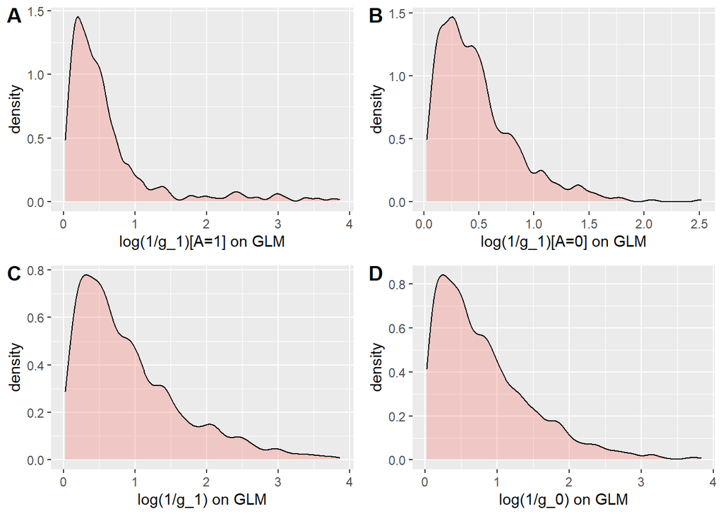

```r
plot(bdt_glm)
```

```r
lib = c("SL.gam", "SL.glm.interaction")
bdt_sl = bdt(Y, A, W=X, M = m, outcome_type = "continuous",
             seed = seeds, gbound = 0, gGLM = FALSE, SL.library = lib)
```

```
## Small number of replications may lead to unreliable estimates.
##
## Estimating ate using user-supplied SuperLearner functions for g
```

```r
summary(bdt_sl)
```

```
##
##
## True simulated data effect:  0.96587
##
## Mean and median bias, SE and coverage rates of AIPTW and TMLE with the ps estimation by SL:
##
##       MeanBias Med.Bias    SE   Cov.
## AIPTW -0.19861 -0.22624 0.24039 0.9
##  TMLE -0.22330 -0.26344 0.23057 0.8
##
##
## Summary of propensity scores truncated at gbound 0
##
##                         Min.   1st Qu.    Median      Mean   3rd Qu.      Max.
## P(A=1|X) for all 0.004906575 0.1451183 0.4281296 0.4799114 0.8434000 0.9976601
## P(A=0|X) for all 0.002339859 0.1566000 0.5718704 0.5200886 0.8548817 0.9950934
## P(A=1|X) for A=1 0.039040214 0.5460922 0.8364801 0.7356132 0.9600246 0.9976601
## P(A=0|X) for A=0 0.033960364 0.6518615 0.8244238 0.7585920 0.9283130 0.9950934
```

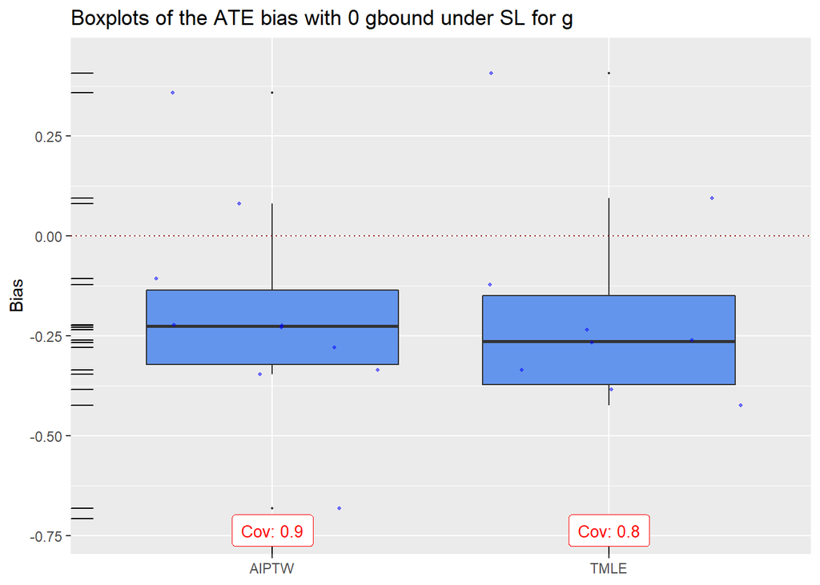

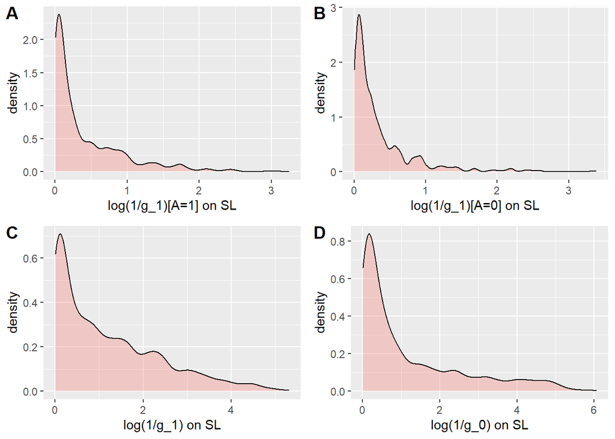

```r
plot(bdt_sl)
```

## Acknowledgement

This project would have been infeasible without guidance and helps from Mireille Schnitzer and Asma Bahamyirou for package and coding suggestions, Hadley Wickham for his two great books **Advanced R** and **R Packages**.